# Pauta Tarea 3

Facultad de Economía y Negocios, Universidad de Chile, Chile

2018-10-15 (updated: 2018-10-16)

**Instrucciones**

1. Esta tarea debe ser entregada en grupos de máximo 3 personas.
2. Se debe enviar una carpeta comprimida que contenga: un archivo .Rproj (proyecto en R), un script y un breve informe en R Markdown con sus resultados, incluyendo tablas, gráficos, etc., según corresponda. El formato del infome puede ser word o pdf y se debe el archivo Rmd.
3. El nombre del archivo comprimido debe ser “Tarea 3-R-Uchile Apellido 1-Apellido 2-Apellido 3”.
4. El asunto del email con su tarea debe ser “Tarea 3-R-Uchile Apellido 1-Apellido 2-Apellido 3”.
5. La fecha de entrega es el Sábado 13 de Octubre del 2018 hasta las 23:59 hrs al correo del curso: r2018uchile@gmail.com.

> “The goal is to turn data into information, and information into insight”

> – *Carly Fiorina, CEO de HP desde 1999 hasta 2005*

```r
if(!require("pacman")) install.packages("pacman")
p_load("tidyverse", "maps", "lubridate", "plotly")
```

# Pregunta 1

## Pregunta 1.1

Usted en la Tarea 1 (pregunta 1.5) tuvo que identificar el porcentaje de películas estrenadas por década. A partir del *data frame* obtenido, construya un *pie chart* usando la librería *plotly*. (*20 puntos*)

```r
movie_dataset <- read.csv("Datasets/movie_dataset.csv")

# porcentaje de peliculas por decada
decade_movies <- movie_dataset %>%
                 na.omit() %>%
                 mutate(year = year(release_date), decade = year - year%%10, n = n()) %>%
                 group_by(decade, n) %>%
                 summarise(n()) %>%
                 mutate(percentage = `n()`/n)
```

```r
p <- plot_ly(decade_movies, labels = ~ decade, values = ~percentage, type = "pie") %>%
         layout(title = "Porcentaje de películas por década",
         xaxis = list(showgrid = FALSE, zeroline = FALSE, showticklabels = FALSE),
         yaxis = list(showgrid = FALSE, zeroline = FALSE, showticklabels = FALSE))
p
```

[interactive chart not shown]

## Pregunta 1.2

Considerando la Tarea 1 (pregunta 1.6), indentifique el presupuesto promedio (*budget*) por estado y presentelo esta vez utilizando el mapa de los Estados Unidos. (*20 puntos*)

```r
# cargamos la lista y la transformas a character
lista_estados <- read.csv("Datasets/estados.csv") %>%
                 as.matrix() %>%
                 as.character()
```

```r
# Promedio de presupuesto por estado de Estados Unidos
keywords <- read.csv("Datasets/keywords.csv")

peliculas_estado <- keywords %>%
                    filter(keywords %in% lista_estados) %>%
                    right_join(movie_dataset, by = "id") %>%
                    group_by(keywords) %>%
                    summarise(count=n(), mean(budget)) %>%
                    mutate(nombre_estado=keywords) %>%
                    right_join(
                      tibble(nombre_estado=lista_estados),
                      by="nombre_estado"
                    ) %>%
                    select(nombre_estado, count, `mean(budget)`) %>%
                    mutate(
                      count=ifelse(is.na(count),0,count)
                    ) %>%
                    rename("presupuesto" = `mean(budget)`) %>%
                    arrange(desc(count))
```

```r
mapa_estados <- map_data("state")
```

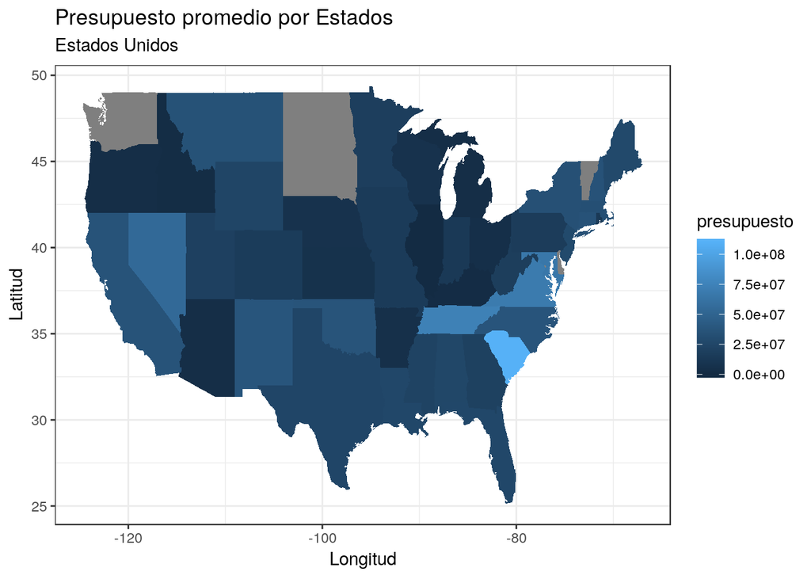

```r
g1 <- ggplot(peliculas_estado) +
      geom_map(aes(map_id = nombre_estado, fill = presupuesto), map = mapa_estados) +
      expand_limits(x = mapa_estados$long, y = mapa_estados$lat) +
      labs(title ="Presupuesto promedio por Estados", subtitle = "Estados Unidos") + xlab("Longitud") + ylab("Latitud") +
      theme_bw()
g1
```

# Pregunta 2

A partir de las variables seleccionadas del *World Development Indicators* de su Tarea 2, represente en un mapa los valores que asume cada variable en 1990 y 2015.

# Pregunta 3

Visite el sitio web http://datos.gob.cl/ y descargue una base de datos de su preferencia[^1], justificando su elección. Luego, represente los datos seleccionados en un mapa de una o varias de las comunas de la región Metropolitana. Los mapas vectoriales pueden ser descargados de [https://www.bcn.cl](https://www.bcn.cl/siit/mapas_vectoriales).

[^1]: Debe contener las comunas de la región Metropolitana.

**Disclaimer** : La información contenida en esta página está bajo una [Licencia Creative Commons Atribución-NoComercial-SinDerivadas 4.0 Internacional](http://creativecommons.org/licenses/by-nc-nd/4.0/) y fue construida bajo mi rol como ayudante (*Teacher Assistant*) de la Catedra Topicos en economía y negocios utilizando R ( *R for economy and business* ).